# ISYE 6501

2022-09-04

# Submission HW4 | Fall 22

- Ashish Dhiman | ashish.dhiman@gatech.edu
- Abhinav Arun | aarun60@gatech.edu
- Anshit Verma | averma373@gatech.edu

*Analysis Notes are marked with Red header: #Analysis

## Question 10.1

```r
set.seed(77)

library(randomForest)
library(ggplot2)
library(cowplot)
library(ggplot2)
library(reshape2)
library(grid)
library(MASS)
library(rpart)
library(rpart.plot)
```

```r
crime_data<-read.table(file = "./uscrime.txt", sep = "\t",header=TRUE)
head(crime_data)
```

|  | M | So | Ed | Po1 | Po2 | LF | M.F | Pop | NW | U1 | U2 | Wealth | Ineq | Prob | Time | Crime |
| --- | --- | --- | --- | --- | --- | --- | --- | --- | --- | --- | --- | --- | --- | --- | --- | --- |
| 1 | 15.1 | 1 | 9.1 | 5.8 | 5.6 | 0.510 | 95.0 | 33 | 30.1 | 0.108 | 4.1 | 3940 | 26.1 | 0.084602 | 26.2011 | 791 |
| 2 | 14.3 | 0 | 11.3 | 10.3 | 9.5 | 0.583 | 101.2 | 13 | 10.2 | 0.096 | 3.6 | 5570 | 19.4 | 0.029599 | 25.2999 | 1635 |
| 3 | 14.2 | 1 | 8.9 | 4.5 | 4.4 | 0.533 | 96.9 | 18 | 21.9 | 0.094 | 3.3 | 3180 | 25.0 | 0.083401 | 24.3006 | 578 |
| 4 | 13.6 | 0 | 12.1 | 14.9 | 14.1 | 0.577 | 99.4 | 157 | 8.0 | 0.102 | 3.9 | 6730 | 16.7 | 0.015801 | 29.9012 | 1969 |
| 5 | 14.1 | 0 | 12.1 | 10.9 | 10.1 | 0.591 | 98.5 | 18 | 3.0 | 0.091 | 2.0 | 5780 | 17.4 | 0.041399 | 21.2998 | 1234 |
| 6 | 12.1 | 0 | 11.0 | 11.8 | 11.5 | 0.547 | 96.4 | 25 | 4.4 | 0.084 | 2.9 | 6890 | 12.6 | 0.034201 | 20.9995 | 682 |

```r
dim(crime_data)
```

```
## [1] 47 16
```

```r
summary(crime_data)
```

```
##        M               So               Ed             Po1
##  Min.   :11.90   Min.   :0.0000   Min.   : 8.70   Min.   : 4.50
##  1st Qu.:13.00   1st Qu.:0.0000   1st Qu.: 9.75   1st Qu.: 6.25
##  Median :13.60   Median :0.0000   Median :10.80   Median : 7.80
##  Mean   :13.86   Mean   :0.3404   Mean   :10.56   Mean   : 8.50
##  3rd Qu.:14.60   3rd Qu.:1.0000   3rd Qu.:11.45   3rd Qu.:10.45
##  Max.   :17.70   Max.   :1.0000   Max.   :12.20   Max.   :16.60
##       Po2               LF              M.F              Pop
##  Min.   : 4.100   Min.   :0.4800   Min.   : 93.40   Min.   :  3.00
##  1st Qu.: 5.850   1st Qu.:0.5305   1st Qu.: 96.45   1st Qu.: 10.00
##  Median : 7.300   Median :0.5600   Median : 97.70   Median : 25.00
##  Mean   : 8.023   Mean   :0.5612   Mean   : 98.30   Mean   : 36.62
##  3rd Qu.: 9.700   3rd Qu.:0.5930   3rd Qu.: 99.20   3rd Qu.: 41.50
##  Max.   :15.700   Max.   :0.6410   Max.   :107.10   Max.   :168.00
##        NW              U1                U2            Wealth
##  Min.   : 0.20   Min.   :0.07000   Min.   :2.000   Min.   :2880
##  1st Qu.: 2.40   1st Qu.:0.08050   1st Qu.:2.750   1st Qu.:4595
##  Median : 7.60   Median :0.09200   Median :3.400   Median :5370
##  Mean   :10.11   Mean   :0.09547   Mean   :3.398   Mean   :5254
##  3rd Qu.:13.25   3rd Qu.:0.10400   3rd Qu.:3.850   3rd Qu.:5915
##  Max.   :42.30   Max.   :0.14200   Max.   :5.800   Max.   :6890
##       Ineq            Prob              Time           Crime
##  Min.   :12.60   Min.   :0.00690   Min.   :12.20   Min.   : 342.0
##  1st Qu.:16.55   1st Qu.:0.03270   1st Qu.:21.60   1st Qu.: 658.5
##  Median :17.60   Median :0.04210   Median :25.80   Median : 831.0
##  Mean   :19.40   Mean   :0.04709   Mean   :26.60   Mean   : 905.1
##  3rd Qu.:22.75   3rd Qu.:0.05445   3rd Qu.:30.45   3rd Qu.:1057.5
##  Max.   :27.60   Max.   :0.11980   Max.   :44.00   Max.   :1993.0
```

### Data Distribution and Pairwise Corelation

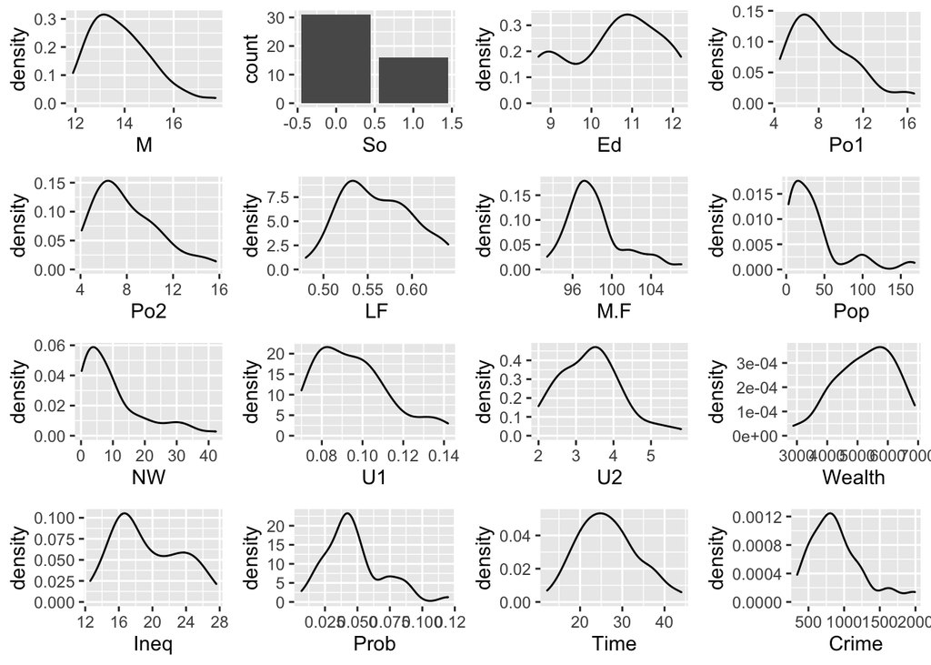

```r
my_plots <- lapply(names(crime_data), function(var_x){
  p <-
    ggplot(crime_data) +
    aes_string(var_x)

  if(var_x %in% list("So")) {
    p <- p + geom_bar()

  } else {
    p <- p + geom_density()
  }

})

plot_grid(plotlist = my_plots)
```

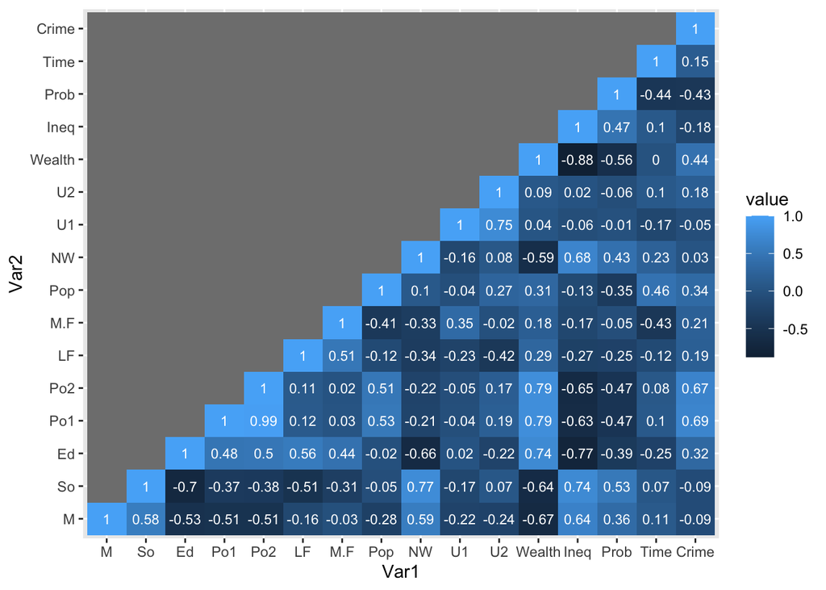

```r
### Correlation
cormat <- round(cor(crime_data),2)
cormat[upper.tri(cormat)] <- NA
melted_cormat <- melt(cormat)
# plotting the correlation heatmap

ggplot(data = melted_cormat, aes(x=Var1, y=Var2,
                                   fill=value)) +
geom_tile() +
geom_text(aes(Var1, Var2, label = value),
          color = "white", size = 3)
```

### Decision Tree

#### Training and evaluating on the same training dataset (not a good method for generalizing) , better to do cross validation to get optimal hyperparameters. Splitting into training and testing set does not make sense here as we have only 47 datapoints.

```r
# Vanilla decision tree with a fixed value of complexity parameter of 0.01 and minsplit of 20
reg_tree<-rpart(Crime~.,data=crime_data,method="anova",control=c(cp=0.01,minsplit=20))
rmse<-sqrt(sum((crime_data$Crime - predict(reg_tree,type=c("vector")))**2)/nrow(crime_data))
rmse
```

```
## [1] 252.9856
```

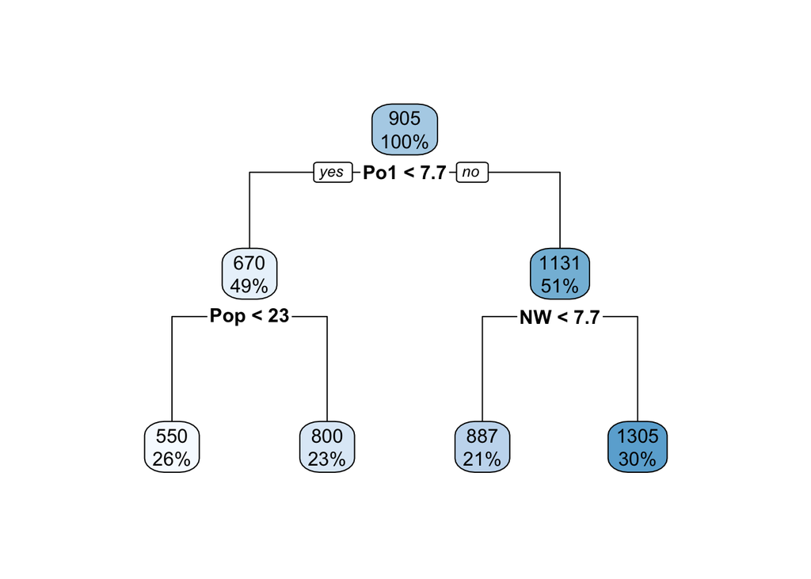

```r
rpart.plot(reg_tree)
```

**#Analysis**

#### Perform hyperparameter tuning minsplit and cp(complexity hyperparameter)

```r
folds <- sample(rep(1:5, length.out = nrow(crime_data)), size = nrow(crime_data), replace = F)
pred_table<-data.frame(min_split=numeric(0),cp=double(0),rmse=double(0))
for(j in seq(0.001,0.02,0.001)){
for(i in seq(5,25,2)){
  CV_mse <- lapply(1:5, function(x){ #5 corresponds to the number of folds defined earlier
  model <- rpart(Crime ~ ., data = crime_data[folds != x,],method="anova",control=c(minsplit=i,cp=j))
  preds <- predict(model,  crime_data[folds == x,], type="vector")
  sum_sse<-sum((crime_data[folds==x,"Crime"]-preds)**2)
  rmse<-sqrt(sum_sse/nrow(crime_data[folds==x,]))
  #total_rmse<-total_rmse+rmse
  return(rmse)
   })
pred_table[nrow(pred_table)+1,]=c(i,j,mean(unlist(CV_mse)))
}
}
```

#### Identifying the optimal value of the hyperparameters cp and min_split

```r
options(scipen=999)
pred_table[which.min(pred_table$rmse),c("min_split","cp")]
```

|  | min_split | cp |
| --- | --- | --- |
| 1 | 5 | 0.001 |

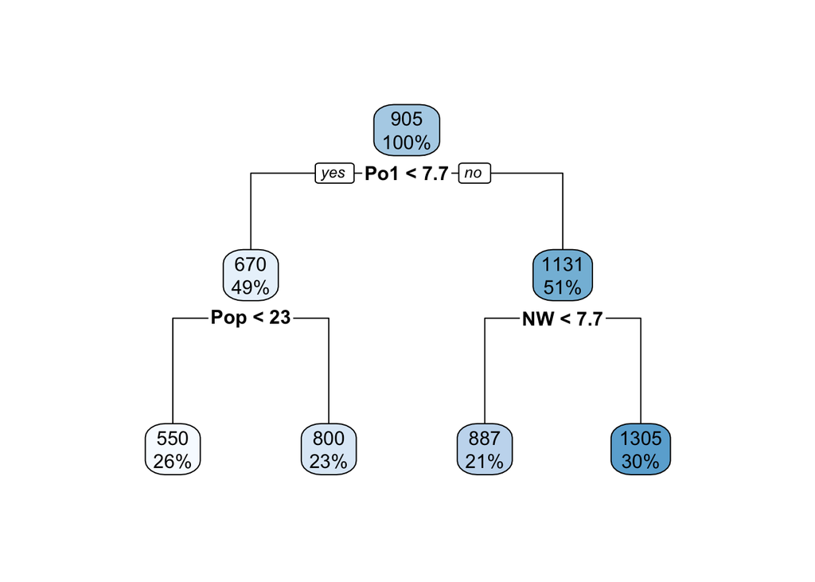

```r
reg_cv_tree<-rpart(Crime~.,data=crime_data,method="anova",control=c(cp=0.001,minsplit=15))
rpart.plot(reg_cv_tree)
```

**#Analysis**

- Note: The above set of optimal parameters reproduces the same decision tree that we had done initially with fixed values of these 2 parameters.This can be because of less # of datapoints. We can try reducing the number of minsplits which will lead to a higher variance model and we can try iterating to get the optimal maxDepth hyperparameter.

```r
pred_table<-data.frame(min_split=numeric(0),maxDepth=double(0),rmse=double(0))
for(j in seq(2,15,1)){
for(i in seq(5,25,2)){
  CV_mse <- lapply(1:5, function(x){ #5 corresponds to the number of folds defined earlier
  model <- rpart(Crime ~ ., data = crime_data[folds != x,],method="anova",control=c(minsplit=i,maxdepth=j))
  preds <- predict(model,  crime_data[folds == x,], type="vector")
  sum_sse<-sum((crime_data[folds==x,"Crime"]-preds)**2)
  rmse<-sqrt(sum_sse/nrow(crime_data[folds==x,]))
  #total_rmse<-total_rmse+rmse
  return(rmse)
   })
pred_table[nrow(pred_table)+1,]=c(i,j,mean(unlist(CV_mse)))
}
}
#rpart.plot(rpart(Crime ~ ., data = crime_data,method="anova",minsplit=10,cp=0.01))
#plot(pred_table)
```

**#Analysis**

- Identifying the optimal value of the hyperparameter maxDepth (which comes out to be 3 with min_split within range of 5-15 (rmse is same for different values of min_split))

```r
options(scipen=999)
pred_table[which.min(pred_table$rmse),c("maxDepth")]
```

```
## [1] 3
```

```r
reg_tree_final<-rpart(Crime~.,data=crime_data,method="anova",control=c(cp=0.001,minsplit=15,maxdepth=2))
rmse_final<-sqrt(sum((crime_data$Crime - predict(reg_tree_final,type=c("vector")))**2)/nrow(crime_data))
rmse_final
```

```
## [1] 252.9856
```

### Random Forest

```r
crime_df <- crime_data
crime_df$So <- factor(crime_df$So)
```

#### Build Vanilla RF model

```r
rf_model_v0 = randomForest(Crime ~ ., data = crime_df, importance=TRUE)
summary(rf_model_v0)
```

```
##                 Length Class  Mode
## call              4    -none- call
## type              1    -none- character
## predicted        47    -none- numeric
## mse             500    -none- numeric
## rsq             500    -none- numeric
## oob.times        47    -none- numeric
## importance       30    -none- numeric
## importanceSD     15    -none- numeric
## localImportance   0    -none- NULL
## proximity         0    -none- NULL
## ntree             1    -none- numeric
## mtry              1    -none- numeric
## forest           11    -none- list
## coefs             0    -none- NULL
## y                47    -none- numeric
## test              0    -none- NULL
## inbag             0    -none- NULL
## terms             3    terms  call
```

```r
rmse_func = function(true,predicted){
  (mean((true-predicted)^2))**0.5
}

rmse_func(true = crime_df$Crime, predicted=rf_model_v0$predicted)
```

```
## [1] 300.4338
```

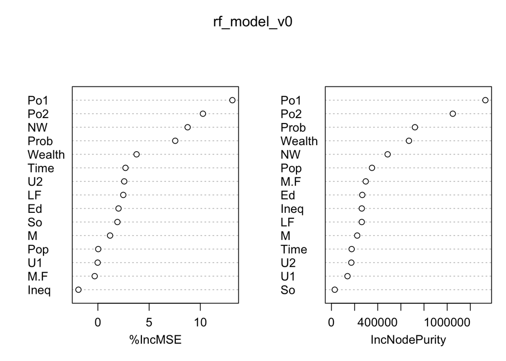

```r
varImpPlot(rf_model_v0,sort = TRUE)
```

**#Analysis**

Variable Importance here is given basis two metrics, drop in MSE when the variable is not included in feature set, and second the Information gain (or purity) of a node, if the variable is used to split it.

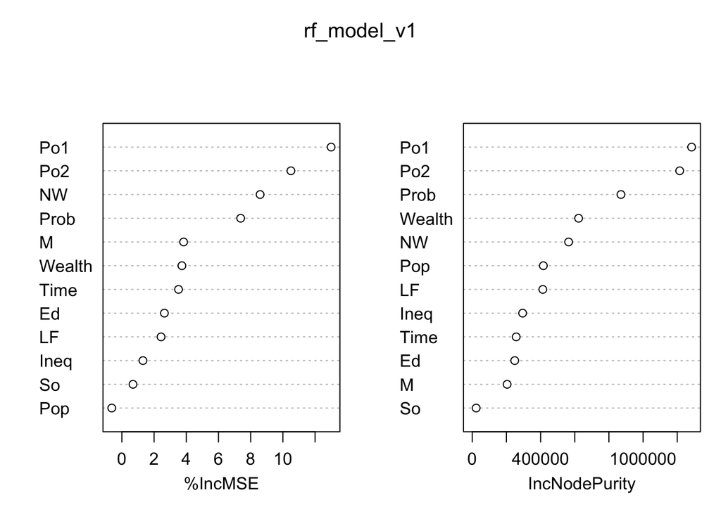

```r
rf_model_v1 = randomForest(Crime ~ . -U1 -M.F -U2, data = crime_df, importance = TRUE)
varImpPlot(rf_model_v1)
```

### Build RF and tune hyperparams with CV

#### Build CV folds

```r
n_folds = 5
folds <- sample(rep(1:n_folds, length.out = nrow(crime_df)), size = nrow(crime_df), replace = F)

table(folds)
```

```
## folds
##  1  2  3  4  5
## 10 10  9  9  9
```

**#Analysis**

We have created uniform CV folds here.

#### Function for RF on CV fold

```r
CV_rf_func = function(test_fold, ntree1, mtry1){
  model1 <- randomForest(Crime ~ ., data = crime_df[folds != test_fold,],
                        ntree = ntree1, mtry=mtry1)
  model2 <- randomForest(Crime ~ . -U1 -M.F -U2, data = crime_df[folds != test_fold,],
                        ntree = ntree1, mtry=mtry1)
  model3 <- randomForest(Crime ~ . -U1 -U2 -Time, data = crime_df[folds != test_fold,],
                        ntree = ntree1, mtry=mtry1)

  preds1 <- predict(model1,  crime_df[folds == test_fold,])
  preds2 <- predict(model2,  crime_df[folds == test_fold,])
  preds3 <- predict(model3,  crime_df[folds == test_fold,])

  rmse1 = rmse_func(true = crime_df[folds == test_fold,"Crime"],predicted = preds1)
  rmse2 = rmse_func(true = crime_df[folds == test_fold,"Crime"],predicted = preds2)
  rmse3 = rmse_func(true = crime_df[folds == test_fold,"Crime"],predicted = preds3)

  return(c(rmse1,rmse2,rmse3))
}
```

```r
rmse_list1=c()
rmse_list2=c()
rmse_list3=c()
ntree_list=c()
mtry_list=c()

for (ntree_i in seq(30,130,10)) {
  for (mtry_i in seq(2,6,1)) {
    #RMSE on each CV Fold for ntree_i,mtry_i
    rmse_cv_all = lapply(seq(1:5), function(fold)
      CV_rf_func(test_fold = fold, ntree1 = ntree_i, mtry1 = mtry_i))
    rmse_cv_df = do.call(rbind.data.frame, rmse_cv_all)
    rmse_cv1 = mean(unlist(rmse_cv_df[,1]))
    rmse_cv2 = mean(unlist(rmse_cv_df[,2]))
    rmse_cv3 = mean(unlist(rmse_cv_df[,3]))
    #print (paste("For tree:",ntree_i,"mtry:",mtry_i))
    rmse_list1 = c(rmse_list1, rmse_cv1)
    rmse_list2 = c(rmse_list2, rmse_cv2)
    rmse_list3 = c(rmse_list3, rmse_cv3)
    ntree_list = c(ntree_list, ntree_i)
    mtry_list = c(mtry_list, mtry_i)
}
}
```

```r
rmse_df = cbind.data.frame(ntree_list,mtry_list,
                           rmse_list1,rmse_list2,rmse_list3)
names(rmse_df)=c("ntree","mtry","rmse_model1","rmse_model2","rmse_model3")
```

```r
rmse_df
```

| ntree | mtry | rmse_model1 | rmse_model2 | rmse_model3 |
| --- | --- | --- | --- | --- |
| 30 | 2 | 291.5338 | 274.4771 | 300.7148 |
| 30 | 3 | 293.8038 | 273.2007 | 281.1680 |
| 30 | 4 | 285.2069 | 272.4092 | 282.1933 |
| 30 | 5 | 274.3285 | 273.7038 | 281.3919 |
| 30 | 6 | 287.6059 | 280.0679 | 276.9732 |
| 40 | 2 | 292.4228 | 276.5089 | 277.4315 |
| 40 | 3 | 280.1168 | 267.0782 | 264.6720 |
| 40 | 4 | 283.4656 | 271.3495 | 277.6849 |
| 40 | 5 | 297.1108 | 267.6519 | 278.9607 |
| 40 | 6 | 279.9734 | 274.5137 | 279.0340 |

[output cut: 45 more lines]

### Let us study the impact of these two hyper-parameters on RMSE

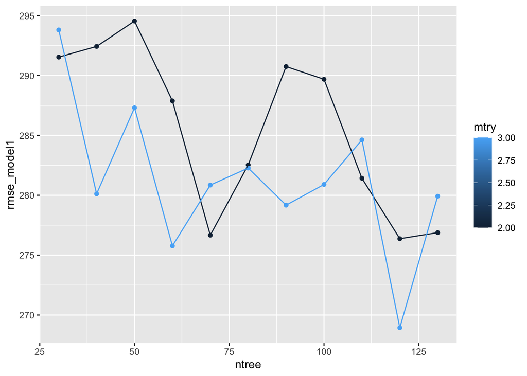

```r
ggplot(rmse_df[rmse_df$mtry<4,], aes(x = ntree, y = rmse_model1, group = mtry, color = mtry)) +
  geom_point() + geom_line()
```

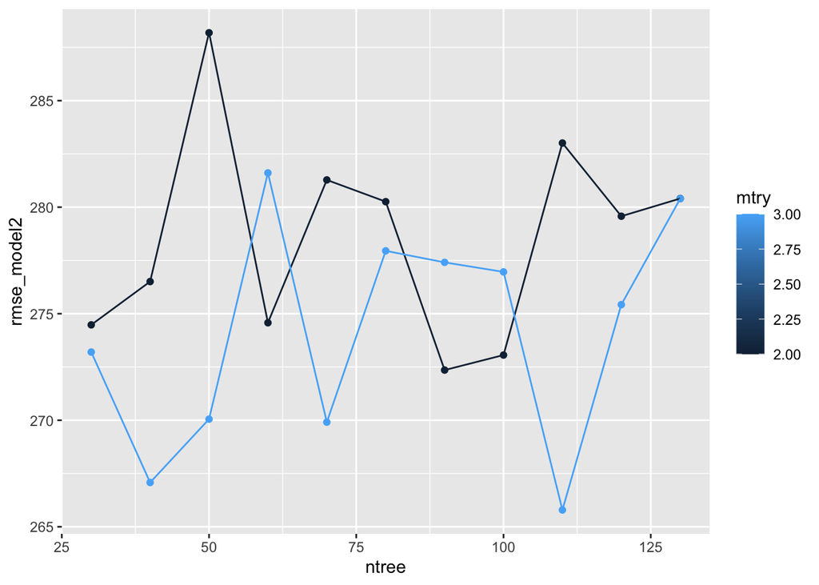

```r
ggplot(rmse_df[rmse_df$mtry<4,], aes(x = ntree, y = rmse_model2, group = mtry, color = mtry)) +
  geom_point() + geom_line()
```

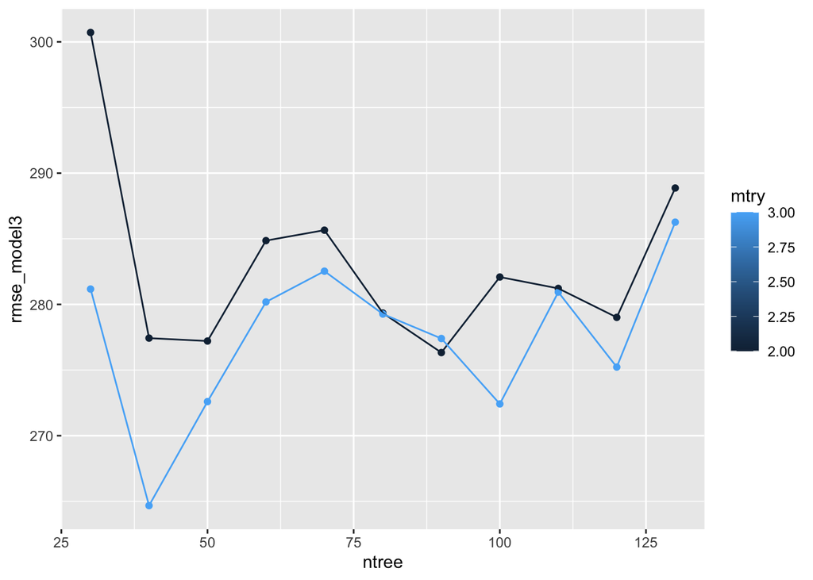

```r
ggplot(rmse_df[rmse_df$mtry<4,], aes(x = ntree, y = rmse_model3, group = mtry, color = mtry)) +
  geom_point() + geom_line()
```

**#Analysis**

Because our data is so small; the effect of ntree and mtry is very sporadic, with high interaction between them. Also the trend varies as per the choice of the model(i.e the choice of predictors).

Ideally we would have expected the RMSE to exhibit a ‘U’ shaped trend with out hyper parameters, where adding complexity to model (i.e. more num of trees to average upon or more features to split nodes upon) first decreases RMSE, but after a point it starts overfitting, and RMSE starts increasing again.

```r
print ("Min RMSE model 1")
```

```
## [1] "Min RMSE model 1"
```

```r
rmse_df[which.min(rmse_df[,"rmse_model1"]),]
```

|  | ntree | mtry | rmse_model1 | rmse_model2 | rmse_model3 |
| --- | --- | --- | --- | --- | --- |
| 33 | 90 | 4 | 267.1695 | 281.8266 | 293.7127 |

```r
print ("Min RMSE model 2")
```

```
## [1] "Min RMSE model 2"
```

```r
rmse_df[which.min(rmse_df[,"rmse_model2"]),]
```

|  | ntree | mtry | rmse_model1 | rmse_model2 | rmse_model3 |
| --- | --- | --- | --- | --- | --- |
| 42 | 110 | 3 | 284.6236 | 265.789 | 280.9367 |

```r
print ("Min RMSE model 3")
```

```
## [1] "Min RMSE model 3"
```

```r
rmse_df[which.min(rmse_df[,"rmse_model3"]),]
```

|  | ntree | mtry | rmse_model1 | rmse_model2 | rmse_model3 |
| --- | --- | --- | --- | --- | --- |
| 7 | 40 | 3 | 280.1168 | 267.0782 | 264.672 |

### Best Model is therefore given for:

Not only thus by RMSE, but by intution too this is a simpler model since it has lesser features, lower number of trees, as well as lower number of features to split on in RF.

Using the above hyper-parameters we can build the best model on full data.

```r
rf_final_model <- randomForest(Crime ~ . -U1 -M.F -U2, data = crime_df, ntree = 40, mtry=3, importance = TRUE)
rmse_func(true=crime_df$Crime,predicted = rf_final_model$predicted)
```

```
## [1] 262.7157
```

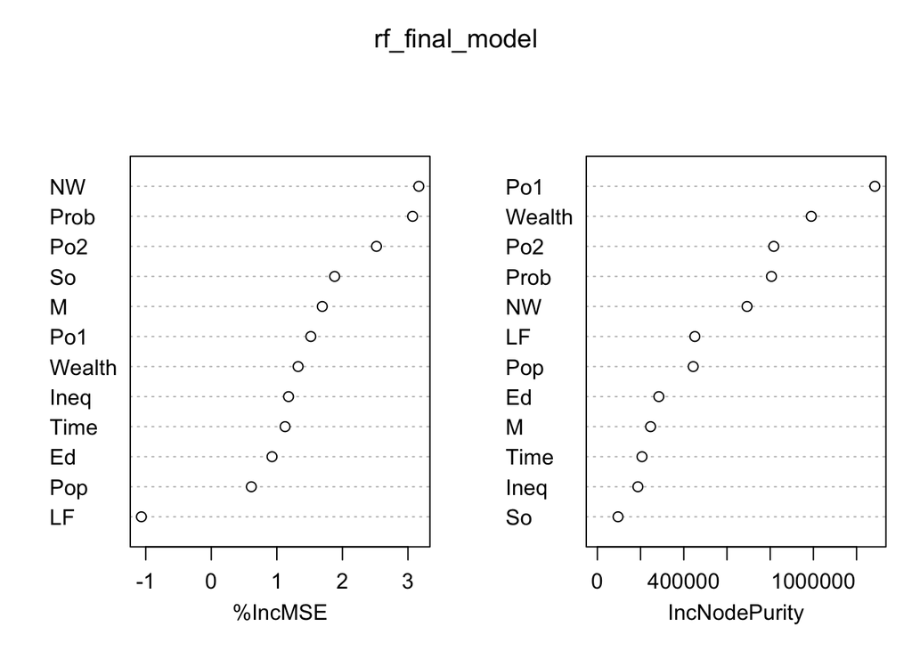

```r
varImpPlot(rf_final_model)
```

**#Analysis**

From the variable importance plot we see, that the following variable feature very highly in Importance:

1. Po2
2. NW
3. Prob

### Comparison between Decision Tree and Random Forest

**#Analysis**

Note: while the above 3 variables are also significant features here is the variable importance of variable “Pop”. While this variable is very important for Decision trees, it is not that important for Random Forest. One possible reason for this could be the notion of randomness involved in RF.

Another point to note here is that after Hyperparameter tuning, Decision tree is giving lower RMSE, and is most likely over-fitting the data-set, in comparison to Random Forest, and if we had a test data, RF model would most likely perform better, because of better generalization.

## Question 10.2

### Logistic Regression finds many use cases in the healthcare analytics domain , one of them being predicting the probability of readmission within 30 days of being discharged . The above problem depends on lot of factors , the primary ones being discussed below :

- Dicharge Disposition : The discharge disposition/location code is an important factor for determining the probability of readmission . People with a relatively high risk score and requiring post acute care when discharged directly to home are more prone to getting readmitted.
- Length of Stay : The period/length of stay also has a strong predictive power on the probability of readmission. Both low and high values are correlated with higher readmission rate.Low length of stay can lead to readmission due to patient not being treated properly without proper diagnosis and people with higher length of stay get readmitted due to Hospital acquired diseases.
- Risk Score : The overall risk score of a patient based on past medical history and demographics is also a good prediction variable for the probability of readmission.
- Change in medication/procedure during hospitalization : This is also a significant feature related with higher readmission rates. People who have seen greater changes in procedure/prescribed medicine are more prone to getting readmitted.
- Number of ED/IP visits within the rolling 1 year : This utilization metric is also a good predictor as it encapsulates the overall profile of a patient . Patients with higher ED/IP visits are more prone to getting readmitted within 30 days of being discharged.

## Question 10.3

```r
german_data = read.table("./germancredit.txt")
german_data
```

| V1 | V2 | V3 | V4 | V5 | V6 | V7 | V8 | V9 | V10 | V11 | V12 | V13 | V14 | V15 | V16 | V17 | V18 | V19 | V20 | V21 |
| --- | --- | --- | --- | --- | --- | --- | --- | --- | --- | --- | --- | --- | --- | --- | --- | --- | --- | --- | --- | --- |
| A11 | 6 | A34 | A43 | 1169 | A65 | A75 | 4 | A93 | A101 | 4 | A121 | 67 | A143 | A152 | 2 | A173 | 1 | A192 | A201 | 1 |
| A12 | 48 | A32 | A43 | 5951 | A61 | A73 | 2 | A92 | A101 | 2 | A121 | 22 | A143 | A152 | 1 | A173 | 1 | A191 | A201 | 2 |
| A14 | 12 | A34 | A46 | 2096 | A61 | A74 | 2 | A93 | A101 | 3 | A121 | 49 | A143 | A152 | 1 | A172 | 2 | A191 | A201 | 1 |
| A11 | 42 | A32 | A42 | 7882 | A61 | A74 | 2 | A93 | A103 | 4 | A122 | 45 | A143 | A153 | 1 | A173 | 2 | A191 | A201 | 1 |
| A11 | 24 | A33 | A40 | 4870 | A61 | A73 | 3 | A93 | A101 | 4 | A124 | 53 | A143 | A153 | 2 | A173 | 2 | A191 | A201 | 2 |
| A14 | 36 | A32 | A46 | 9055 | A65 | A73 | 2 | A93 | A101 | 4 | A124 | 35 | A143 | A153 | 1 | A172 | 2 | A192 | A201 | 1 |
| A14 | 24 | A32 | A42 | 2835 | A63 | A75 | 3 | A93 | A101 | 4 | A122 | 53 | A143 | A152 | 1 | A173 | 1 | A191 | A201 | 1 |
| A12 | 36 | A32 | A41 | 6948 | A61 | A73 | 2 | A93 | A101 | 2 | A123 | 35 | A143 | A151 | 1 | A174 | 1 | A192 | A201 | 1 |
| A14 | 12 | A32 | A43 | 3059 | A64 | A74 | 2 | A91 | A101 | 4 | A121 | 61 | A143 | A152 | 1 | A172 | 1 | A191 | A201 | 1 |
| A12 | 30 | A34 | A40 | 5234 | A61 | A71 | 4 | A94 | A101 | 2 | A123 | 28 | A143 | A152 | 2 | A174 | 1 | A191 | A201 | 2 |

[output cut: 990 more lines]

```r
cols = colnames(german_data)
for(i in seq(1, length(cols))){
  if(class(german_data[, cols[i]]) == "character"){
    german_data[, cols[i]]= as.factor(german_data[, cols[i]])
  }
}
```

### Exploratory Data Analysis

```r
summary(german_data)
```

```
##    V1            V2         V3            V4            V5          V6
##  A11:274   Min.   : 4.0   A30: 40   A43    :280   Min.   :  250   A61:603
##  A12:269   1st Qu.:12.0   A31: 49   A40    :234   1st Qu.: 1366   A62:103
##  A13: 63   Median :18.0   A32:530   A42    :181   Median : 2320   A63: 63
##  A14:394   Mean   :20.9   A33: 88   A41    :103   Mean   : 3271   A64: 48
##            3rd Qu.:24.0   A34:293   A49    : 97   3rd Qu.: 3972   A65:183
##            Max.   :72.0             A46    : 50   Max.   :18424
##                                     (Other): 55
##    V7            V8          V9        V10           V11          V12
##  A71: 62   Min.   :1.000   A91: 50   A101:907   Min.   :1.000   A121:282
##  A72:172   1st Qu.:2.000   A92:310   A102: 41   1st Qu.:2.000   A122:232
##  A73:339   Median :3.000   A93:548   A103: 52   Median :3.000   A123:332
##  A74:174   Mean   :2.973   A94: 92              Mean   :2.845   A124:154
##  A75:253   3rd Qu.:4.000                        3rd Qu.:4.000
##            Max.   :4.000                        Max.   :4.000
##
##       V13          V14        V15           V16          V17
##  Min.   :19.00   A141:139   A151:179   Min.   :1.000   A171: 22
##  1st Qu.:27.00   A142: 47   A152:713   1st Qu.:1.000   A172:200
##  Median :33.00   A143:814   A153:108   Median :1.000   A173:630
##  Mean   :35.55                         Mean   :1.407   A174:148
##  3rd Qu.:42.00                         3rd Qu.:2.000
##  Max.   :75.00                         Max.   :4.000
##
##       V18          V19        V20           V21
##  Min.   :1.000   A191:596   A201:963   Min.   :1.0
##  1st Qu.:1.000   A192:404   A202: 37   1st Qu.:1.0
##  Median :1.000                         Median :1.0
##  Mean   :1.155                         Mean   :1.3
##  3rd Qu.:1.000                         3rd Qu.:2.0
##  Max.   :2.000                         Max.   :2.0
##
```

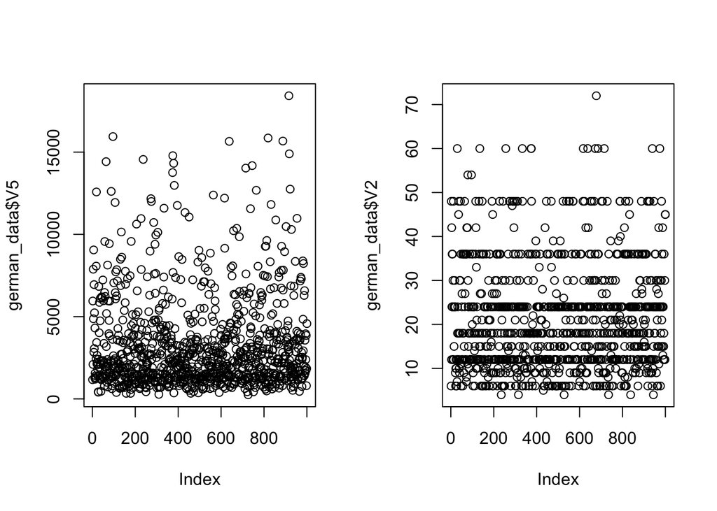

```r
par(mfrow=(c(1,2)))
plot(german_data$V5)
plot(german_data$V2)
```

2 features have suspiciously large max values (comparing to the 3rd quartile).

```r
# (1 = Good, 2 = Bad) -> (0 = Good, 1 = Bad)
german_data['V21'] = lapply(german_data['V21'], function(x){
  x-1
})
german_data[,"V21"] = as.factor(german_data[,"V21"])
german_data
```

| V1 | V2 | V3 | V4 | V5 | V6 | V7 | V8 | V9 | V10 | V11 | V12 | V13 | V14 | V15 | V16 | V17 | V18 | V19 | V20 | V21 |
| --- | --- | --- | --- | --- | --- | --- | --- | --- | --- | --- | --- | --- | --- | --- | --- | --- | --- | --- | --- | --- |
| A11 | 6 | A34 | A43 | 1169 | A65 | A75 | 4 | A93 | A101 | 4 | A121 | 67 | A143 | A152 | 2 | A173 | 1 | A192 | A201 | 0 |
| A12 | 48 | A32 | A43 | 5951 | A61 | A73 | 2 | A92 | A101 | 2 | A121 | 22 | A143 | A152 | 1 | A173 | 1 | A191 | A201 | 1 |
| A14 | 12 | A34 | A46 | 2096 | A61 | A74 | 2 | A93 | A101 | 3 | A121 | 49 | A143 | A152 | 1 | A172 | 2 | A191 | A201 | 0 |
| A11 | 42 | A32 | A42 | 7882 | A61 | A74 | 2 | A93 | A103 | 4 | A122 | 45 | A143 | A153 | 1 | A173 | 2 | A191 | A201 | 0 |
| A11 | 24 | A33 | A40 | 4870 | A61 | A73 | 3 | A93 | A101 | 4 | A124 | 53 | A143 | A153 | 2 | A173 | 2 | A191 | A201 | 1 |
| A14 | 36 | A32 | A46 | 9055 | A65 | A73 | 2 | A93 | A101 | 4 | A124 | 35 | A143 | A153 | 1 | A172 | 2 | A192 | A201 | 0 |
| A14 | 24 | A32 | A42 | 2835 | A63 | A75 | 3 | A93 | A101 | 4 | A122 | 53 | A143 | A152 | 1 | A173 | 1 | A191 | A201 | 0 |
| A12 | 36 | A32 | A41 | 6948 | A61 | A73 | 2 | A93 | A101 | 2 | A123 | 35 | A143 | A151 | 1 | A174 | 1 | A192 | A201 | 0 |
| A14 | 12 | A32 | A43 | 3059 | A64 | A74 | 2 | A91 | A101 | 4 | A121 | 61 | A143 | A152 | 1 | A172 | 1 | A191 | A201 | 0 |
| A12 | 30 | A34 | A40 | 5234 | A61 | A71 | 4 | A94 | A101 | 2 | A123 | 28 | A143 | A152 | 2 | A174 | 1 | A191 | A201 | 1 |

[output cut: 990 more lines]

```r
split_data = function(dataset){
  ## Sampling train and test data

  ## 75% of the sample size
  smp_size <- floor(0.75 * nrow(dataset))

  ## set the seed to make your partition reproducible
  set.seed(123)
  train_ind <- sample(seq_len(nrow(dataset)), size = smp_size)

  train <- dataset[train_ind, ]
  test <- dataset[-train_ind, ]
  return(list("train"=train, "test"=test))
}
```

### Splitting the data into train and test

```r
df_list = split_data(german_data)
train = df_list$train
test = df_list$test
summary(test$V21)
```

```
##   0   1
## 169  81
```

### Training vanilla model with all features

```r
model <- glm(V21 ~.,family=binomial(link='logit'),data=train)
model
```

```
##
## Call:  glm(formula = V21 ~ ., family = binomial(link = "logit"), data = train)
##
## Coefficients:
## (Intercept)        V1A12        V1A13        V1A14           V2        V3A31
##  -0.4737109   -0.2596540   -0.9051153   -1.6490939    0.0315589    0.3471446
##       V3A32        V3A33        V3A34        V4A41       V4A410        V4A42
##  -0.6184599   -0.7187931   -1.3089145   -1.7150890   -1.5395491   -0.7860931
##       V4A43        V4A44        V4A45        V4A46        V4A48        V4A49
##  -0.8120295    0.2934752    0.5010264   -0.3840035   -1.5458780   -0.9467900
##          V5        V6A62        V6A63        V6A64        V6A65        V7A72
##   0.0001611   -0.4933097   -0.8792324   -1.5669965   -1.1737063    0.5171219
##       V7A73        V7A74        V7A75           V8        V9A92        V9A93
##   0.2503677   -0.5742281   -0.0799781    0.3779061   -0.1540225   -0.8253587
##       V9A94      V10A102      V10A103          V11      V12A122      V12A123
##  -0.2009796    0.6112512   -0.8955903    0.0260380    0.3095034    0.4929289
##     V12A124          V13      V14A142      V14A143      V15A152      V15A153
##   0.9321510   -0.0048175   -0.3803003   -0.4647767   -0.5157531   -0.8693444
##         V16      V17A172      V17A173      V17A174          V18      V19A192
##   0.2023044   -0.1773829   -0.0888132   -0.3521802    0.4949639   -0.3770873
##     V20A202
##  -1.3672141
##
## Degrees of Freedom: 749 Total (i.e. Null);  701 Residual
## Null Deviance:       905.9
## Residual Deviance: 652.5     AIC: 750.5
```

```r
summary(model)
```

```
##
## Call:
## glm(formula = V21 ~ ., family = binomial(link = "logit"), data = train)
##
## Deviance Residuals:
##     Min       1Q   Median       3Q      Max
## -2.3552  -0.6818  -0.3515   0.6634   2.8548
##
## Coefficients:
##                Estimate  Std. Error z value      Pr(>|z|)
## (Intercept) -0.47371093  1.28736774  -0.368      0.712897
## V1A12       -0.25965398  0.25905124  -1.002      0.316186
## V1A13       -0.90511531  0.42993466  -2.105      0.035270 *
## V1A14       -1.64909389  0.27735859  -5.946 0.00000000275 ***
## V2           0.03155885  0.01064523   2.965      0.003031 **
## V3A31        0.34714462  0.67581899   0.514      0.607486
## V3A32       -0.61845988  0.54212499  -1.141      0.253950
## V3A33       -0.71879307  0.59642059  -1.205      0.228135
## V3A34       -1.30891449  0.54393589  -2.406      0.016112 *
## V4A41       -1.71508900  0.43890221  -3.908 0.00009318695 ***
## V4A410      -1.53954907  0.98543549  -1.562      0.118217
## V4A42       -0.78609314  0.31250084  -2.515      0.011887 *
## V4A43       -0.81202948  0.29428339  -2.759      0.005792 **
## V4A44        0.29347519  0.88384815   0.332      0.739857
## V4A45        0.50102638  0.68975501   0.726      0.467604
## V4A46       -0.38400348  0.46439856  -0.827      0.408303
## V4A48       -1.54587798  1.38555555  -1.116      0.264546
## V4A49       -0.94679002  0.40561609  -2.334      0.019585 *
## V5           0.00016106  0.00005115   3.149      0.001638 **
## V6A62       -0.49330971  0.34506335  -1.430      0.152826
## V6A63       -0.87923244  0.51991926  -1.691      0.090819 .
## V6A64       -1.56699654  0.59972071  -2.613      0.008978 **
## V6A65       -1.17370628  0.32138547  -3.652      0.000260 ***
## V7A72        0.51712187  0.51690796   1.000      0.317110
## V7A73        0.25036773  0.50272417   0.498      0.618468
## V7A74       -0.57422812  0.53654476  -1.070      0.284514
## V7A75       -0.07997809  0.50387596  -0.159      0.873885
## V8           0.37790613  0.10387583   3.638      0.000275 ***
## V9A92       -0.15402249  0.45274144  -0.340      0.733706
## V9A93       -0.82535867  0.44670757  -1.848      0.064653 .
```

[output cut: 14 more lines]

```
## V17A173     -0.08881318  0.76357307  -0.116      0.907405
## V17A174     -0.35218022  0.76212042  -0.462      0.644005
## V18          0.49496393  0.29269819   1.691      0.090829 .
## V19A192     -0.37708727  0.23882489  -1.579      0.114353
## V20A202     -1.36721410  0.76443249  -1.789      0.073690 .
## ---
## Signif. codes:  0 '***' 0.001 '**' 0.01 '*' 0.05 '.' 0.1 ' ' 1
##
## (Dispersion parameter for binomial family taken to be 1)
##
##     Null deviance: 905.90  on 749  degrees of freedom
## Residual deviance: 652.51  on 701  degrees of freedom
## AIC: 750.51
##
## Number of Fisher Scoring iterations: 5
```

```r
get_roc_plot_and_auc = function(model, test){
  p <- predict(model, newdata=test[, 1:(length(test)-1)], type="response")
  pr <- prediction(p, test$V21)
  prf <- performance(pr, measure = "tpr", x.measure = "fpr")
  auc <- performance(pr, measure = "auc")
  auc <- auc@y.values[[1]]
  return (list("prf"=prf, "auc"=auc, "prediction"=p))
}
```

### Plotting the ROC Curve and calculating AUC

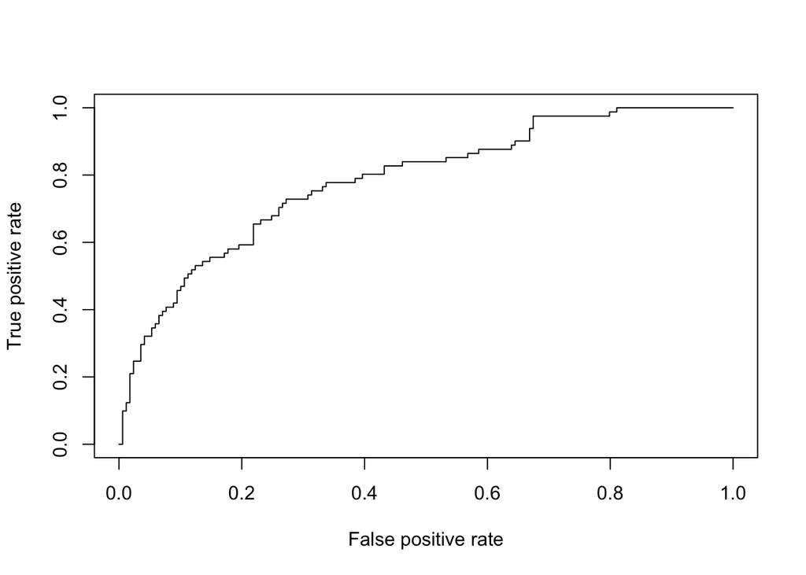

```r
roc = get_roc_plot_and_auc(model, test)
plot(roc$prf)
```

```r
roc$auc
```

```
## [1] 0.7846446
```

**#Analysis**

As we can see that AUC value is 0.7846446 that is close to 1. Hence our model is above average in being able to separate between classes.

```r
predicted = ifelse(roc$prediction > 0.5,1,0)
cor = confusionMatrix(data=as.factor(predicted), reference=as.factor(test$V21), positive="1")
cor
```

```
## Confusion Matrix and Statistics
##
##           Reference
## Prediction   0   1
##          0 145  37
##          1  24  44
##
##                Accuracy : 0.756
##                  95% CI : (0.6979, 0.8079)
##     No Information Rate : 0.676
##     P-Value [Acc > NIR] : 0.003558
##
##                   Kappa : 0.4187
##
##  Mcnemar's Test P-Value : 0.124430
##
##             Sensitivity : 0.5432
##             Specificity : 0.8580
##          Pos Pred Value : 0.6471
##          Neg Pred Value : 0.7967
##              Prevalence : 0.3240
##          Detection Rate : 0.1760
##    Detection Prevalence : 0.2720
##       Balanced Accuracy : 0.7006
##
##        'Positive' Class : 1
##
```

```r
cor$byClass
```

```
##          Sensitivity          Specificity       Pos Pred Value
##            0.5432099            0.8579882            0.6470588
##       Neg Pred Value            Precision               Recall
##            0.7967033            0.6470588            0.5432099
##                   F1           Prevalence       Detection Rate
##            0.5906040            0.3240000            0.1760000
## Detection Prevalence    Balanced Accuracy
##            0.2720000            0.7005990
```

**#Analysis**

With and initial (default) threshold of 0.5, we can see that our model achieves an accuracy of 75.6% with a recall of 54.3% and precision of 64.7%. We can try dropping some statistically insignificant features to better improve the metrics of our model.

### Dropping Features

```r
# We can drop statistically insignificant features
drop.features = german_data
drops <- c("V7","V17", "V11", "V13", "V16", "V12")
drop.features = drop.features[ , !(names(drop.features) %in% drops)]
```

```r
df.list.1 = split_data(drop.features)
train.1 = df.list.1$train
test.1 = df.list.1$test
```

```r
model.1 <- glm(V21 ~.,family=binomial(link='logit'),data=train.1)
model.1
```

```
##
## Call:  glm(formula = V21 ~ ., family = binomial(link = "logit"), data = train.1)
##
## Coefficients:
## (Intercept)        V1A12        V1A13        V1A14           V2        V3A31
##   0.2784340   -0.2363467   -0.8716280   -1.6418090    0.0322317    0.0545614
##       V3A32        V3A33        V3A34        V4A41       V4A410        V4A42
##  -0.8985819   -0.9059482   -1.5046340   -1.6277829   -1.4285749   -0.7403743
##       V4A43        V4A44        V4A45        V4A46        V4A48        V4A49
##  -0.8229680    0.3595115    0.4973945   -0.1717731   -1.9248707   -0.9471413
##          V5        V6A62        V6A63        V6A64        V6A65           V8
##   0.0001489   -0.4711606   -0.8823461   -1.5070678   -1.1870199    0.3685953
##       V9A92        V9A93        V9A94      V10A102      V10A103      V14A142
##  -0.1128736   -0.8820612   -0.1544998    0.6693471   -1.1278093   -0.2900500
##     V14A143      V15A152      V15A153          V18      V19A192      V20A202
##  -0.4640215   -0.5439332   -0.4285479    0.5017881   -0.4265948   -1.2529742
##
## Degrees of Freedom: 749 Total (i.e. Null);  714 Residual
## Null Deviance:       905.9
## Residual Deviance: 669.1     AIC: 741.1
```

```r
summary(model.1)
```

```
##
## Call:
## glm(formula = V21 ~ ., family = binomial(link = "logit"), data = train.1)
##
## Deviance Residuals:
##     Min       1Q   Median       3Q      Max
## -2.3570  -0.6943  -0.3748   0.7088   2.9494
##
## Coefficients:
##                Estimate  Std. Error z value      Pr(>|z|)
## (Intercept)  0.27843402  0.86460351   0.322      0.747425
## V1A12       -0.23634672  0.24984315  -0.946      0.344159
## V1A13       -0.87162801  0.41754139  -2.088      0.036841 *
## V1A14       -1.64180898  0.26885541  -6.107 0.00000000102 ***
## V2           0.03223168  0.01018053   3.166      0.001545 **
## V3A31        0.05456143  0.64097021   0.085      0.932163
## V3A32       -0.89858190  0.51165106  -1.756      0.079047 .
## V3A33       -0.90594824  0.58549129  -1.547      0.121784
## V3A34       -1.50463397  0.53147735  -2.831      0.004640 **
## V4A41       -1.62778289  0.43598050  -3.734      0.000189 ***
## V4A410      -1.42857489  0.99025720  -1.443      0.149125
## V4A42       -0.74037427  0.30034454  -2.465      0.013698 *
## V4A43       -0.82296796  0.28607830  -2.877      0.004018 **
## V4A44        0.35951155  0.87171111   0.412      0.680031
## V4A45        0.49739446  0.65969886   0.754      0.450866
## V4A46       -0.17177313  0.45224470  -0.380      0.704077
## V4A48       -1.92487068  1.35684259  -1.419      0.156004
## V4A49       -0.94714128  0.39276802  -2.411      0.015889 *
## V5           0.00014895  0.00004829   3.085      0.002037 **
## V6A62       -0.47116057  0.32672032  -1.442      0.149277
## V6A63       -0.88234614  0.49658303  -1.777      0.075595 .
## V6A64       -1.50706784  0.57438007  -2.624      0.008695 **
## V6A65       -1.18701989  0.31433062  -3.776      0.000159 ***
## V8           0.36859534  0.10029075   3.675      0.000238 ***
## V9A92       -0.11287364  0.42819813  -0.264      0.792087
## V9A93       -0.88206123  0.42680558  -2.067      0.038766 *
## V9A94       -0.15449982  0.50992661  -0.303      0.761902
## V10A102      0.66934709  0.48459353   1.381      0.167201
## V10A103     -1.12780926  0.47410844  -2.379      0.017369 *
## V14A142     -0.29004997  0.48005888  -0.604      0.545713
## V14A143     -0.46402152  0.27252334  -1.703      0.088627 .
## V15A152     -0.54393315  0.26387741  -2.061      0.039273 *
## V15A153     -0.42854791  0.38272960  -1.120      0.262835
## V18          0.50178813  0.28625443   1.753      0.079612 .
## V19A192     -0.42659478  0.21447828  -1.989      0.046702 *
## V20A202     -1.25297421  0.75265278  -1.665      0.095964 .
## ---
## Signif. codes:  0 '***' 0.001 '**' 0.01 '*' 0.05 '.' 0.1 ' ' 1
##
## (Dispersion parameter for binomial family taken to be 1)
##
##     Null deviance: 905.90  on 749  degrees of freedom
## Residual deviance: 669.06  on 714  degrees of freedom
## AIC: 741.06
##
## Number of Fisher Scoring iterations: 5
```

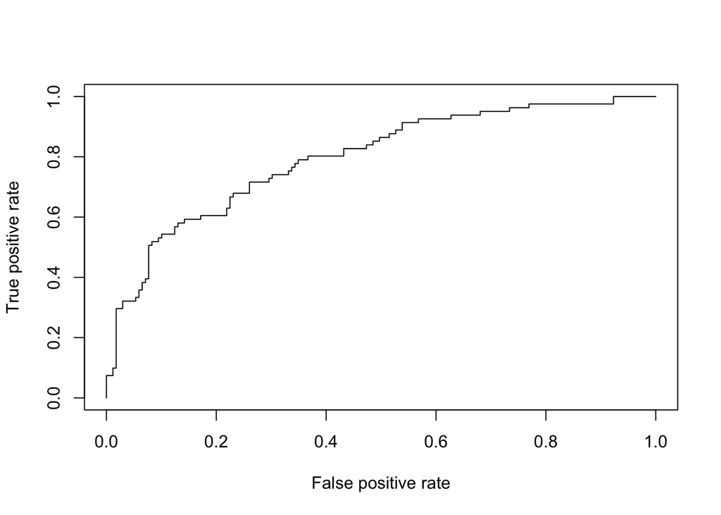

```r
roc.1 = get_roc_plot_and_auc(model.1, test.1)
plot(roc.1$prf)
```

```r
roc.1$auc
```

```
## [1] 0.7961137
```

**#Analysis**

We can observe that dropping statistically insignificant features help us achieve a higher AUC value, which translates to a better risk discrimination. In other words, this increases our model’s ability to separate between the classes.

```r
predicted.1 = ifelse(roc.1$prediction > 0.5,1,0)
cor.1 = confusionMatrix(data=as.factor(predicted.1), reference=as.factor(test.1$V21), positive="1")
cor.1
```

```
## Confusion Matrix and Statistics
##
##           Reference
## Prediction   0   1
##          0 149  37
##          1  20  44
##
##                Accuracy : 0.772
##                  95% CI : (0.7149, 0.8225)
##     No Information Rate : 0.676
##     P-Value [Acc > NIR] : 0.0005478
##
##                   Kappa : 0.4494
##
##  Mcnemar's Test P-Value : 0.0340692
##
##             Sensitivity : 0.5432
##             Specificity : 0.8817
##          Pos Pred Value : 0.6875
##          Neg Pred Value : 0.8011
##              Prevalence : 0.3240
##          Detection Rate : 0.1760
##    Detection Prevalence : 0.2560
##       Balanced Accuracy : 0.7124
##
##        'Positive' Class : 1
##
```

```r
cor.1$byClass
```

```
##          Sensitivity          Specificity       Pos Pred Value
##            0.5432099            0.8816568            0.6875000
##       Neg Pred Value            Precision               Recall
##            0.8010753            0.6875000            0.5432099
##                   F1           Prevalence       Detection Rate
##            0.6068966            0.3240000            0.1760000
## Detection Prevalence    Balanced Accuracy
##            0.2560000            0.7124333
```

**#Analysis**

Again we can observe that with the initial (default) value of threshold - 0.5, we have increased the accuracy of our model. While the recall remains unchanged, we were able to increase the precision.

### Determining Threshold by F-Beta Value

```r
get_recall_and_precision = function(cor){
  cor_table = data.frame(cor$table)
  tn = cor_table[cor_table$Prediction==0 & cor_table$Reference==0, "Freq"]
  fn = cor_table[cor_table$Prediction==0 & cor_table$Reference==1, "Freq"]
  tp = cor_table[cor_table$Prediction==1 & cor_table$Reference==1, "Freq"]
  fp = cor_table[cor_table$Prediction==1 & cor_table$Reference==0, "Freq"]
  recall = tp / (tp + fn)
  precision = tp / (tp + fp)
  return (c("recall"=recall, "precision"=precision))
}
```

**#Analysis**

We can use the F-Beta value for determining the best value of threshold. As we are given that a classifying a “bad” customer as “good” is 5 times worse than classifying “good” customer as “bad”. We need to determine the best value of threshold that will help us increase recall (positive class is 1 i.e. “bad”).

```r
rp.df = data.frame("threshold"=double(), "recall"=double(), "precision"=double(), f_beta=double())
for(i in seq(0, 100, 1)){
  beta=2
  predicted.2 = ifelse(roc.1$prediction > i/100,1,0)
  cor.2 = confusionMatrix(data=as.factor(predicted.2), reference=as.factor(test.1$V21), positive = "1")
  rp = get_recall_and_precision(cor.2)
  f_beta = ((1 + beta^2) * rp[2] * rp[1]) / (beta^2 * rp[2] + rp[1])
  rp.df[nrow(rp.df)+1,] = c("threshold"=i/100, rp, f_beta)
}
```

**#Analysis**

```r
rp.df
```

|  | threshold | recall | precision | f_beta |
| --- | --- | --- | --- | --- |
| 1 | 0.00 | 1.00000000 | 0.3240000 | 0.70557491 |
| 2 | 0.01 | 1.00000000 | 0.3347107 | 0.71554770 |
| 3 | 0.02 | 0.97530864 | 0.3376068 | 0.70788530 |
| 4 | 0.03 | 0.97530864 | 0.3526786 | 0.72080292 |
| 5 | 0.04 | 0.97530864 | 0.3708920 | 0.73556797 |
| 6 | 0.05 | 0.96296296 | 0.3842365 | 0.74003795 |
| 7 | 0.06 | 0.95061728 | 0.3908629 | 0.73896353 |
| 8 | 0.07 | 0.93827160 | 0.4000000 | 0.73929961 |
| 9 | 0.08 | 0.93827160 | 0.4175824 | 0.75098814 |
| 10 | 0.09 | 0.92592593 | 0.4213483 | 0.74701195 |

[output cut: 91 more lines]

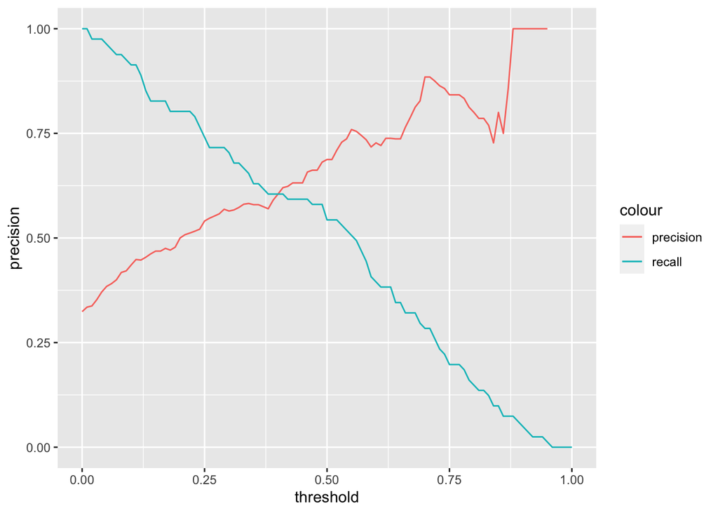

```r
ggplot(rp.df, aes(threshold)) +
  geom_line(aes(y = precision, colour = "precision")) +
  geom_line(aes(y = recall, colour = "recall"))
```

**#Analysis**

As expected, decreasing threshold, makes it easier to classify data points as bad, and so our recall value increases. On the other hand, because on longer threshold, we might no longer be tagging the actual bads, our model precision decreases.

Also the Precision and Recall curver intersect somewhere between 0.3 to 0.4, which is near the bad rate in our dataset.

```r
# Max value of F Beta Score
rp.df[which.max(rp.df$f_beta),]
```

|  | threshold | recall | precision | f_beta |
| --- | --- | --- | --- | --- |
| 12 | 0.11 | 0.9135802 | 0.4484848 | 0.7566462 |

*Plotting the best value of threshold for maximum F2 value*

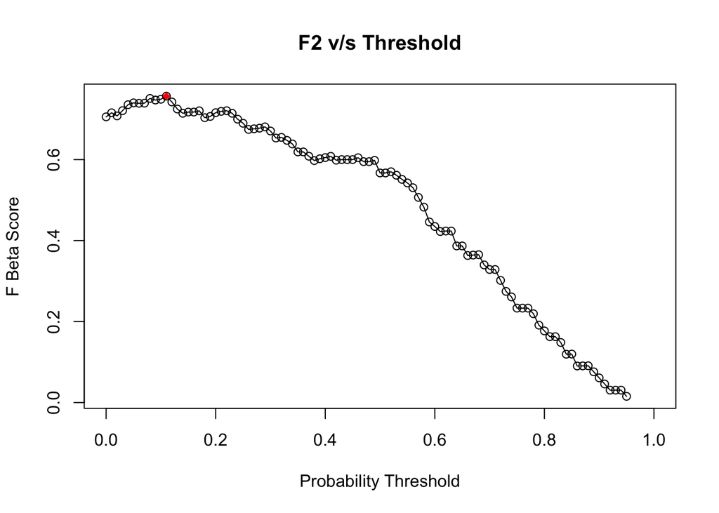

```r
plot(x=rp.df$threshold, y=rp.df$f_beta, type="o", xlab="Probability Threshold", ylab="F Beta Score", main="F2 v/s Threshold")
points(x=rp.df$threshold[which.max(rp.df$f_beta)], y=rp.df$f_beta[which.max(rp.df$f_beta)], pch = 18, col = "red", type = "b", lty = 2)
```

**#Analysis**

We can see from the above plot that best value that minimizes false negatives is 0.11.

### Determining Threshold by Calculating Error Rate

*Note we are deviating here from conventional deviation of error rate, in order to better apply to our use case.

```r
get_cm_value = function(cor){
  cor_table = data.frame(cor.2$table)
  tn = cor_table[cor_table$Prediction==0 & cor_table$Reference==0, "Freq"]
  fn = cor_table[cor_table$Prediction==0 & cor_table$Reference==1, "Freq"]
  tp = cor_table[cor_table$Prediction==1 & cor_table$Reference==1, "Freq"]
  fp = cor_table[cor_table$Prediction==1 & cor_table$Reference==0, "Freq"]
  return(list(tn=tn,fn=fn,tp=tp,fp=fp))
}
```

**#Analysis**

Another way determine the threshold is by calculating the error value by weighing the false negatives more than false positive. As we know that false negatives are 5 time more costly than false positive, we can use that information while calculating our error value. We need to choose the value of threshold which minimizes the error.

```r
## Minimizing the error
## Since we know FN is 5 times worse than FP, we minimize the error that gives us the best threshold

error.df = data.frame("threshold"=double(), "error"=double())
for(i in seq(0, 100, 1)){
  beta=2
  predicted.2 = ifelse(roc.1$prediction > i/100,1,0)
  cor.2 = confusionMatrix(data=as.factor(predicted.2), reference=as.factor(test.1$V21), positive = "1")
  cm.values = get_cm_value(cor.2)
  total_error = (5*cm.values$fn + cm.values$fp)/nrow(german_data)
  error.df[nrow(error.df)+1,] = c("threshold"=i/100, "error"=total_error)
}
error.df[which.min(error.df$error),]
```

|  | threshold | error |
| --- | --- | --- |
| 12 | 0.11 | 0.126 |

**#Analysis**

We can again see that our error value is minimum at the threshold value of 0.11. This is in sync with our value of threshold which we determined via F-beta method. This this value of threshold is optimal.

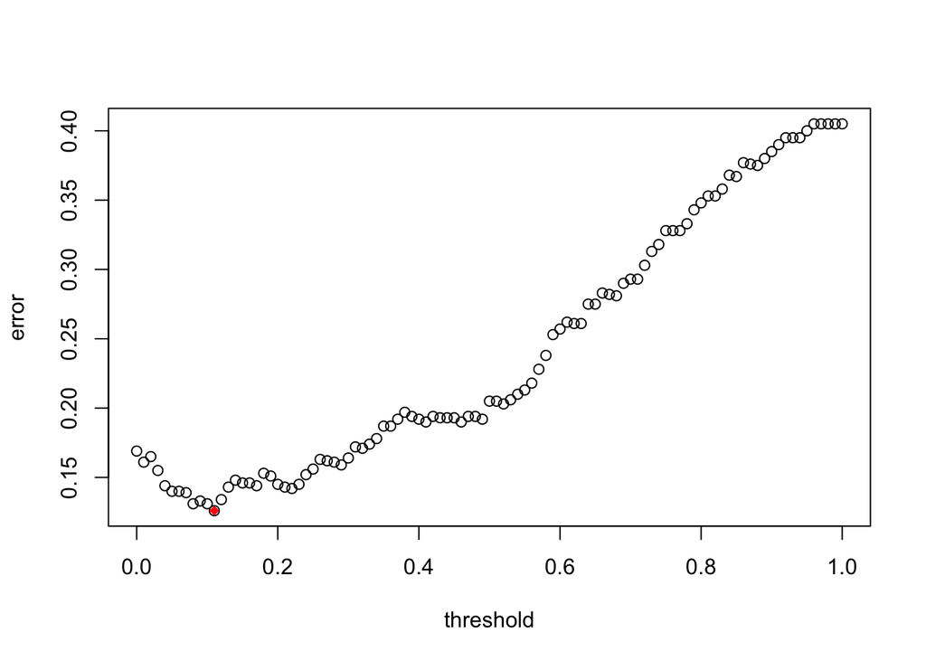

```r
plot(error.df)
points(x=error.df$threshold[which.min(error.df$error)], y=error.df$error[which.min(error.df$error)], pch = 18, col = "red", type = "b", lty = 2)
```

### Final Model

```r
final.predicted = ifelse(roc.1$prediction > 0.11,1,0)
final.cor = confusionMatrix(data=as.factor(final.predicted), reference=as.factor(test.1$V21), positive="1")
final.cor
```

```
## Confusion Matrix and Statistics
##
##           Reference
## Prediction  0  1
##          0 78  7
##          1 91 74
##
##                Accuracy : 0.608
##                  95% CI : (0.5445, 0.6689)
##     No Information Rate : 0.676
##     P-Value [Acc > NIR] : 0.9902
##
##                   Kappa : 0.2954
##
##  Mcnemar's Test P-Value : <0.0000000000000002
##
##             Sensitivity : 0.9136
##             Specificity : 0.4615
##          Pos Pred Value : 0.4485
##          Neg Pred Value : 0.9176
##              Prevalence : 0.3240
##          Detection Rate : 0.2960
##    Detection Prevalence : 0.6600
##       Balanced Accuracy : 0.6876
##
##        'Positive' Class : 1
##
```

```r
final.cor$byClass
```

```
##          Sensitivity          Specificity       Pos Pred Value
##            0.9135802            0.4615385            0.4484848
##       Neg Pred Value            Precision               Recall
##            0.9176471            0.4484848            0.9135802
##                   F1           Prevalence       Detection Rate
##            0.6016260            0.3240000            0.2960000
## Detection Prevalence    Balanced Accuracy
##            0.6600000            0.6875594
```

**#Analysis**

By choosing our threshold to be 0.11, we can achieve a recall value of 0.91, which implies if there are 100 “bad” points we are able to capture 91 of those.

In our test data, the no. of “bad” classified data points was ~33%. We were able to achieve a threshold value of 0.11 which is 1/3rd of that value.